# Version Control with Git

## Scope

- This section will focus on minimal basics to use git for version control
  - Focus on a local git
  - Commands strictly necessary to work on simple analysis projects
- Reasons for this limitation
  - GitHub requires an account
  - Remote repositories are not necessarily compliant with data security and privacy restrictions
    - Infrastructure varies by institution (e.g., locally hosted repositories)
  - The integration of GitHub varies in most IDEs
- This approach can be easily extended to remote repositories (e.g., GitHub, GitLab)

## Git

- Git is a version control tool
- Mostly known through the remote repository GitHub
- Tracks changes in files
  - ‘Checkpoints’ have to be manually set
  - Mainly used for coding, can be used for documents as well (e.g., manuscripts)
- Alternative branches can be created to test things
  - Successful changes can be incorporated
  - Failed tests can be disregarded without affecting the project

## Setting up Git

- [Download](https://git-scm.com/downloads) and install git
  - You can check if git is installed by typing `git` in in your shell
  - This will show a brief overview of git functions

```bash
#| echo: true
#| eval: false
git
```

- Set your username and email
  - This is not a log in/set up of an account
  - Used to track who committed changes

```bash
#| echo: true
#| eval: false
git config --global user.name "Your Name"
git config --global user.email "your@email.com"
```

```bash
#| echo: true
#| eval: false
# Show username and email
git config user.name
git config user.email
```

## A Simplified Git Workflow

1. Initialize git (only required when starting a new project)

```bash
#| echo: true
#| eval: false
git init
```

2. Work on project
3. Add files for commit

```bash
#| echo: true
#| eval: false
# Add specific files
git add script1.R script2.R script1.R
# Add all changed files to commit
git add .
```

4. Commit changes

```bash
#| echo: true
#| eval: false
git commit -m "Added demonstration scripts"
```

5. Repeat 2-4

## Reverting an Erroneous Commit

1. Get the commit hash of commit that broke project

```bash
#| echo: true
#| eval: false
git log
```

2. Revert all changes of that commit
- This reversal is kept as a commit
- Information for the breaking commit are kept in the version history

```bash
#| echo: true
#| eval: false
git revert f07ceb7ab03b6b50d2f65c67b6cd8b280f0f2912
```

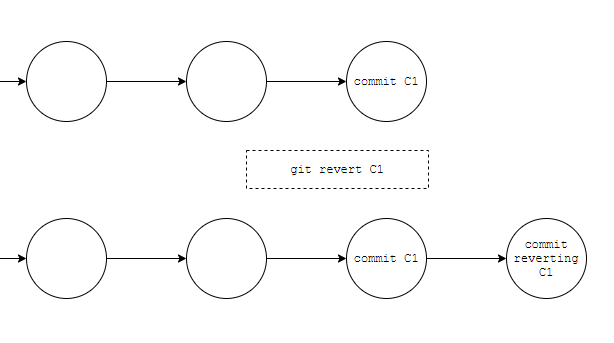

Revert Illustration

- [Source](https://www.freecodecamp.org/news/git-revert-commit-how-to-undo-the-last-commit/)

## Fixing Issues Before They are Committed

- Realize issue before files are added changes are committed
  - Revert uncommitted changes

```bash
#| echo: true
#| eval: false
# Revert uncommitted changes to a specific file
git checkout -- file_that_broke_my_project.R
# Reverting all uncommitted changes
git checkout -- :/
```

## Testing on New Branches

1. Make sure you are up to date
2. Create new branch

```bash
#| echo: true
#| eval: false
git branch trying_something_new
```

3. Switch to New Branch

```bash
#| echo: true
#| eval: false
git checkout trying_something_new
```

4. Implement and test changes
5. They don’t work $\rightarrow$ switch to back main branch and delete branch

```bash
#| echo: true
#| eval: false
git checkout main
git branch -d trying_something_new
```

5. They work $\rightarrow$ switch to main branch and merge branches

```bash
#| echo: true
#| eval: false
git checkout main
git merge trying_something_new
```

## Ignoring Files

- You can tell to ignore files and folders
  - These never show up in git status even if they are changed
- This is achieved with the `.gitignore` file
  - Files can be listed explicitly
  - Patterns can be used to multiple files
    - All files in a folder (data/**)
    - All files of a type (*.sav)
- `renv::dependencies` skips any file listed in `.gitignore`

## Further Material

- This intro to git was inspired by [this video](https://www.youtube.com/watch?v=USjZcfj8yxE) and the [corresponding material](https://zarkom.notion.site/zarkom/Introduction-to-Git-ac396a0697704709a12b6a0e545db049)
- [Git Cheat Sheet](https://training.github.com/downloads/github-git-cheat-sheet.pdf)

# Git Demonstration

Git workflow using the terminal and [GitHub Desktop](https://desktop.github.com/)

# Setting up an R Analysis Project with RStudio

- Open new project in the destination folder
  - `File > New Project`
- Initialize version control using git
- Initialize renv for package management
  - Check `git version control` and `use renv`
- Install required packages
  - Snapshot the package versions with renv
  - Stage and commit changes to the renv using git
- Set up the folder structure
- Import required data
- Start working on the project